# Monthly changes in retail sales in the United States over the last fifteen years

# 3 SARMA modeling of the retail sales changes.

High frequency components in the data don’t interest me so much. There are always low and high season sales throughout the year, which don’t change much over different year. As we can see from this first part of the report, the seansonly adjusted retail sales removed these conponents. So I would be more interested to fit model on the seasonaly adjusted retail sales data.

The exploratory data analysis above also indicates a non-constant mean function and a seasonal period of 12 on the retail sales data. A SARMA model with period equal to 12 might be a proper candidate here.

Before fitting the SARMA model, I detrend the data first.

## 3.1 Detrending data

I fit a linear model to the trend $X_n = \beta_1 t_n + \beta_0$

```
##
## Call:
## lm(formula = `Retail sales` ~ DATE, data = data_ad)
##
## Residuals:
##     Min      1Q  Median      3Q     Max
## -39.044  -4.724  -0.634   7.703  24.388
##
## Coefficients:
##               Estimate Std. Error t value Pr(>|t|)
## (Intercept) -8.209e+01  3.081e+00  -26.64   <2e-16 ***
## DATE         2.890e-02  2.286e-04  126.43   <2e-16 ***
## ---
## Signif. codes:  0 '***' 0.001 '**' 0.01 '*' 0.05 '.' 0.1 ' ' 1
##
## Residual standard error: 12.43 on 335 degrees of freedom
## Multiple R-squared:  0.9795, Adjusted R-squared:  0.9794
## F-statistic: 1.598e+04 on 1 and 335 DF,  p-value: < 2.2e-16
```

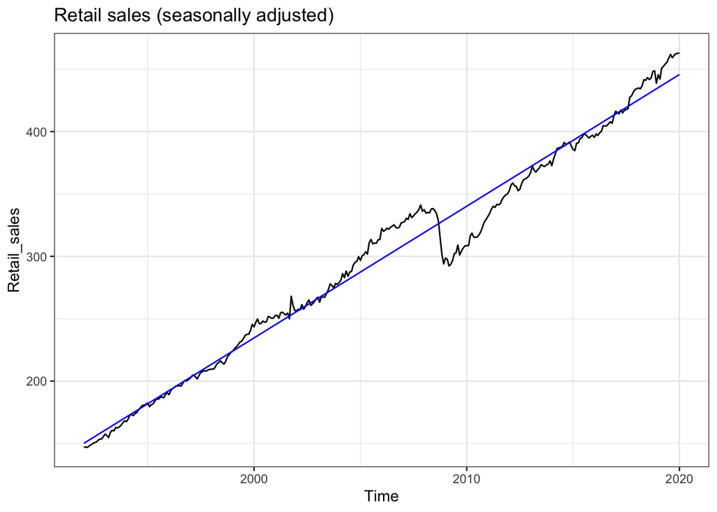

The linear fit looks pretty good except for the severe economic crisis around 2008.

## 3.2 SARMA model

The general form of $SARMA(p,q) \times (P,Q)_{12}$ model[3] is
$$\phi(B)\Phi(B^{12}) (Y_n-\mu) = \psi(B)\Psi(B^{12}) \epsilon_n$$
where $\{\epsilon_n\}$ is a white noise process and

$$\mu = E[Y_n]$$

$$\phi(x)=1-\phi_1 x-\dots -\phi_px^p,$$
$$\psi(x)=1+\psi_1 x+\dots +\psi_qx^q,$$
$$\Phi(x)=1-\Phi_1 x-\dots -\Phi_Px^P,$$
$$\Psi(x)=1+\Psi_1 x+\dots +\Psi_Qx^Q.$$
In order to pick up the orders p and q, I calculate the AIC’s for SARMA(p,q)$\times(1,0)_{12}$.

### 3.2.1 SARMA(p,q)$\times(1,0)_{12}$ model

From this AIC table, I pick up p = 3, q = 2 and fit a SARMA(3,2)$\times(1,0)_{12}$ model.

|  | MA0 | MA1 | MA2 | MA3 | MA4 | MA5 |
| --- | --- | --- | --- | --- | --- | --- |
| AR0 | 2511.38 | 2212.84 | 2041.18 | 1953.51 | 1876.02 | 1856.95 |
| AR1 | 1691.98 | 1693.14 | 1693.03 | 1694.99 | 1695.02 | 1697.02 |
| AR2 | 1693.00 | 1692.91 | 1688.50 | 1688.28 | 1691.80 | 1691.44 |
| AR3 | 1692.79 | 1694.66 | 1687.40 | 1698.84 | 1695.58 | 1698.39 |
| AR4 | 1694.71 | 1688.12 | 1695.10 | 1697.21 | 1694.01 | 1698.59 |
| AR5 | 1694.61 | 1696.68 | 1698.03 | 1697.51 | 1698.68 | 1699.71 |

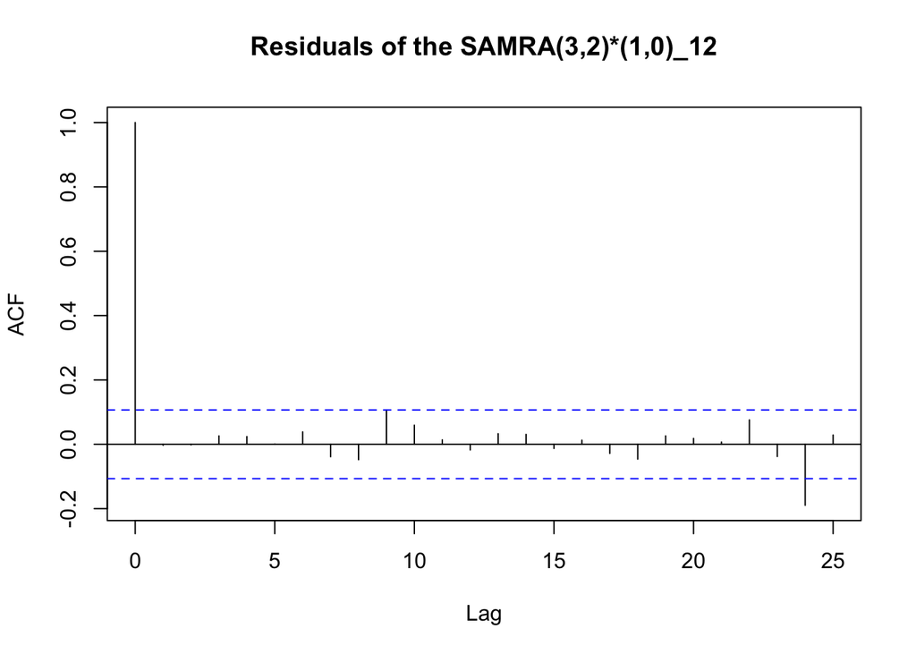

```
##
## Call:
## arima(x = new$detrend, order = c(3, 0, 2), seasonal = list(order = c(1, 0, 0),
##     period = 12))
##
## Coefficients:
##          ar1     ar2      ar3      ma1      ma2     sar1  intercept
##       1.2252  0.5027  -0.7306  -0.3245  -0.6754  -0.0816     0.2565
## s.e.  0.2091  0.4111   0.2028   0.2326   0.2325   0.0552     0.8148
##
## sigma^2 estimated as 8.213:  log likelihood = -835.7,  aic = 1687.4
```

### 3.2.2 SARMA(p,q)$\times (1,1)_{12}$ model

In order to deal with the residual autocorrelation, I decide to try the SARMA(p,q)$\times (1,1)_{12}$ model. Again, I used the AIC values to pick up the model. The AIC table favors p = 3 and q = 2.

|  | MA0 | MA1 | MA2 | MA3 |
| --- | --- | --- | --- | --- |
| AR0 | 2483.11 | 2199.42 | 2037.66 | 1951.35 |
| AR1 | 1681.70 | 1682.68 | 1682.40 | 1684.39 |
| AR2 | 1682.50 | 1682.48 | 1684.26 | 1685.95 |
| AR3 | 1682.16 | 1684.21 | 1678.18 | 1686.76 |

I plot the ACF. There is a significant reduction in the residual autocorrelation at lag = 24.

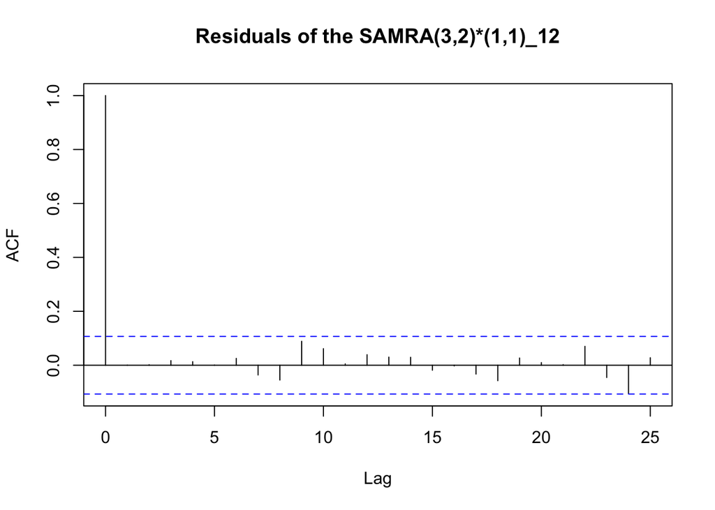

```
##
## Call:
## arima(x = new$detrend, order = c(3, 0, 2), seasonal = list(order = c(1, 0, 1),
##     period = 12))
##
## Coefficients:
##          ar1     ar2      ar3      ma1      ma2    sar1     sma1
##       1.2731  0.4140  -0.6892  -0.3762  -0.6238  0.5815  -0.7547
## s.e.  0.2750  0.5422   0.2677   0.3021   0.3020  0.1289   0.1034
##       intercept
##          0.2787
## s.e.     0.7307
##
## sigma^2 estimated as 7.91:  log likelihood = -830.09,  aic = 1678.18
```

From the model output, I notice that the standard errors for these parameters are all very big, especially for the intercept. Let’s take a look at the qqplot to see whether we can see any violation of the model assumption.

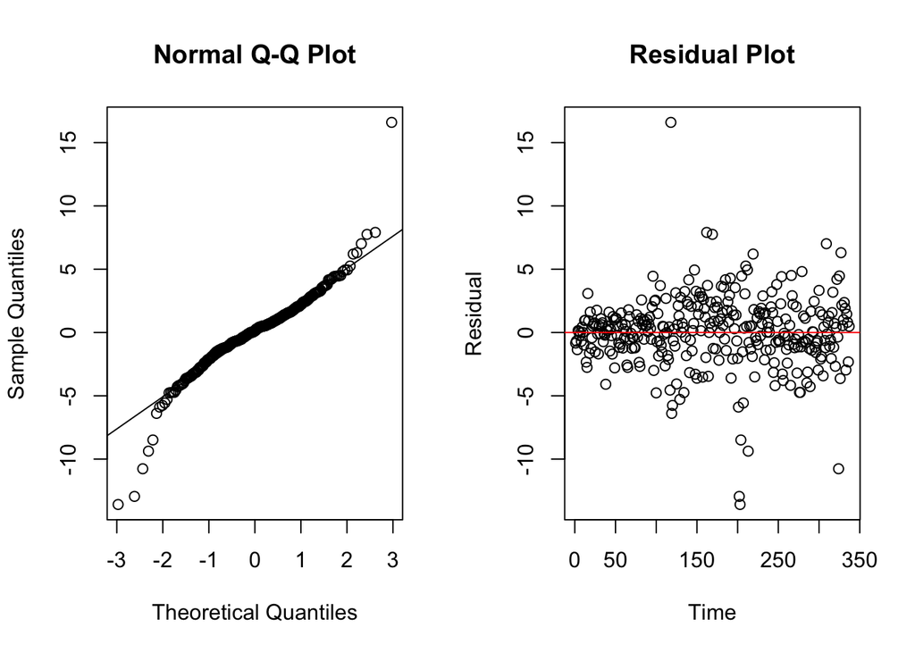

The qqplot shows that about 5% of the points deviate from the line at two ends. But the main body follow a good normal distribution. From the residual plot, we can see there are a few influential points at position 200 and a very high outlier at position 120. The residual plot also shows evidence of heteroscedasticity. Based on the residual plot, I decide to make a log transformation and then fit the SARMA model again.

## 3.3 SARMA(p,q)$\times (1,1)_{12}$ model on the log transformed data

As the growth rate of retail sales is always expected to be stable, I assume the trend doesn’t change through the log transformation. So I use the linear model fitted above and transform it to logarithmic coordinate. The retail sales and trend in the log scale are present in the plot. Then I fit a SARMA model to the different between these two curves.

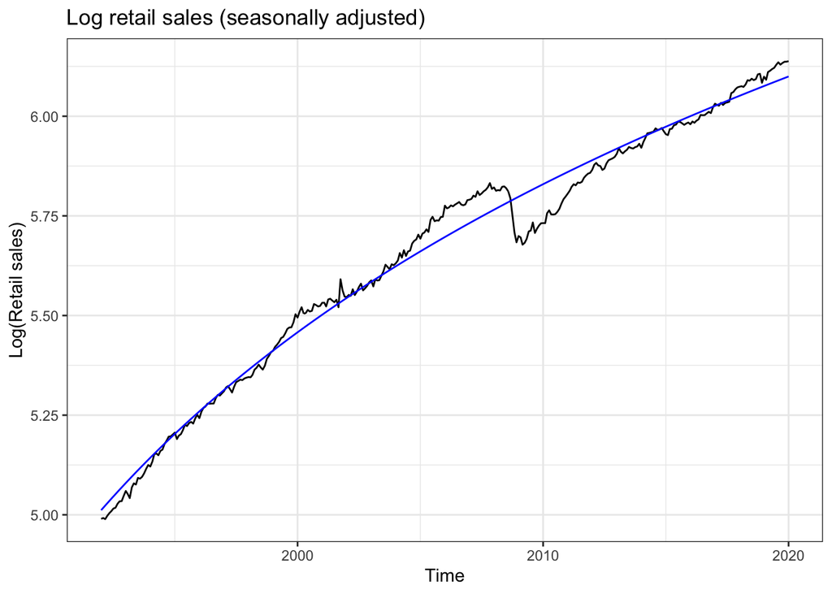

### 3.3.1 SARMA(p,q)$\times(1,1)_{12}$ model on the log transformed detrend retail sales

From the AIC table, I pick up the $SARMA(2,2) \times(1,1)_{12}$.

|  | MA0 | MA1 | MA2 | MA3 |
| --- | --- | --- | --- | --- |
| AR0 | -1391.02 | -1669.60 | -1821.19 | -1897.36 |
| AR1 | -2156.12 | -2156.84 | -2155.28 | -2153.54 |
| AR2 | -2157.01 | -2155.16 | -2159.11 | -2157.14 |
| AR3 | -2155.22 | -2153.63 | -2151.94 | -2152.98 |

```
##
## Call:
## arima(x = new_log$detrend, order = c(2, 0, 2), seasonal = list(order = c(1,
##     0, 1), period = 12))
##
## Coefficients:
##          ar1      ar2      ma1     ma2    sar1     sma1  intercept
##       1.9533  -0.9559  -1.0874  0.1374  0.5747  -0.7450    -0.0002
## s.e.  0.0482   0.0462   0.0710  0.0604  0.1661   0.1361     0.0064
##
## sigma^2 estimated as 9.104e-05:  log likelihood = 1087.55,  aic = -2159.11
```

Comparing the results of this $SARMA(2,2) \times(1,1)_{12}$ fitted on the transformed data with the previous $SARMA(3,2) \times(1,1)_{12}$ fitted on the original, we can see that the standard errors of these parameters get smaller, which is very promising.

The ACF doesn’t show significant autocorrelation among residuals.

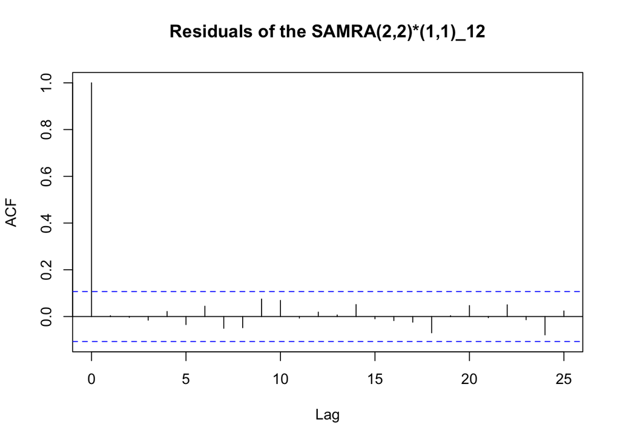

The red curve is from our model $SARMA(2,2) \times(1,1)_{12}$, which is very comparable to the original data.

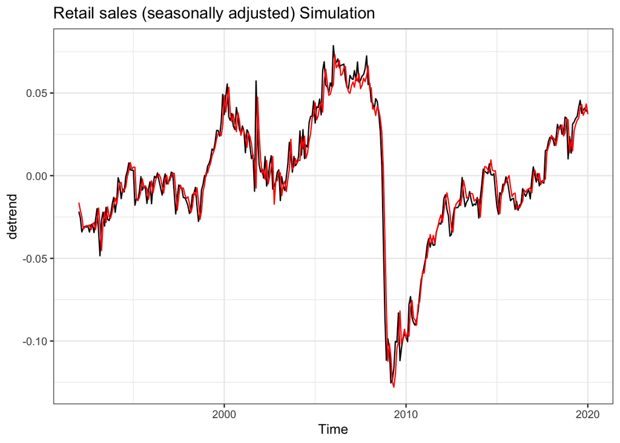

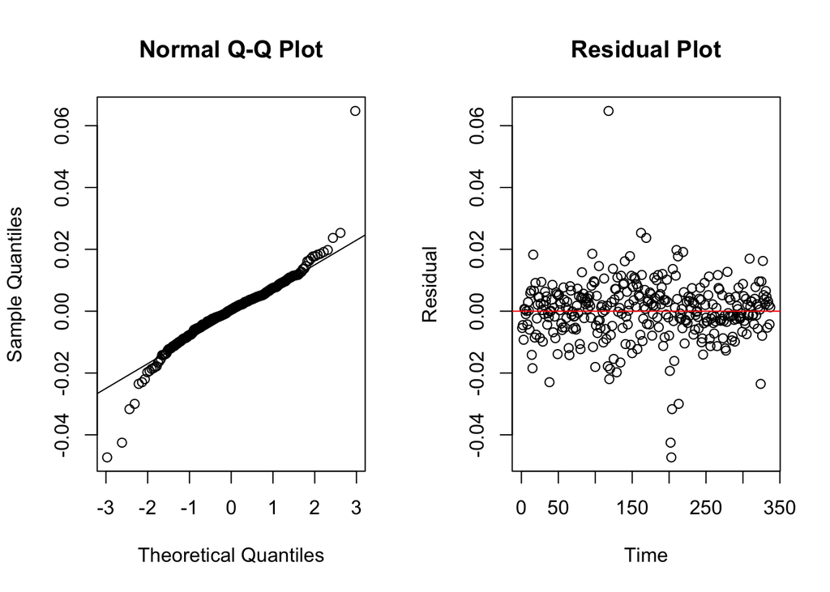

These two diagnostic plots don’t show strong evidence against the normal iid assumption on $\epsilon_n$. It seems that the transformation does deal with the problem of the heteroscedasticity.

In order to check the nurmerical stability of the model, I calculated the roots of the AR, MA, SAR and SMA polynomials respectively.

```
## [1] 1.021714+0.047374i 1.021714-0.047374i
```

```
## [1] 1.062172+0i 6.851046-0i
```

```
## [1] 1.740032+0i
```

```
## [1] 1.342286+0i
```

It seems that all the roots of the AR(SAR) polynomial and the MA(SMA) polynomials are outside the unit circle, this $SARMA(2,2) \times (1,1)$ is an invertible and causal process. The two AR polynomial roots are very close to the unit circle. Let’s do a simulation study.